# PRUEBA-TECNICA-ESTEBAN-CALLE

# Puesta a punto del entorno de trabajo

Creamos directorios e instalación de paquetes (librerías necesarias):

```r
# ## Require carga los paquetes de CRAN y los instala si faltan

packages <- c("here",  # rutas fáciles y reproducibles
          "tidyverse", # data wrangling
          "glue", # f-strings
          "rio", # fácil importación y exportación
          "dplyr", # pipes
          "tibble", # Tibbles functionality
          "purrr", # functional programing,
          "flextable", # table formats,
          "janitor", # data cleaning
          "DataExplorer", # EDA
          "SmartEDA",    # EDA
          "dlookr", # EDA
          "ggstatsplot", # visualization with statistical details"
          "gtsummary",
          "moments",
          "ggpubr",
          "GGally",
          "PerformanceAnalytics",
          "performance",
          "caret",
          "recipes",
          "Boruta",
          "yardstick",
          "ROCR",
          "rio"
)

# Install packages not yet installed
installed_packages <- packages %in% rownames(installed.packages())
if (any(installed_packages == FALSE)) {
  install.packages(packages[!installed_packages])
}

# Packages loading
invisible(lapply(packages, library, character.only = TRUE))


# Creación de directorios
if (!dir.exists(here("Data"))) {
  dir.create(here("Data"))
}
# if (!dir.exists(here("Plots"))) {
#   dir.create(here("Plots"))
# }
# if (!dir.exists(here("Tables"))) {
#   dir.create(here("Tables"))
# }
# if (!dir.exists(here("Models"))) {
#   dir.create(here("Models"))
# }
#
# if (!dir.exists(here("EDA_reports"))) {
#   dir.create(here("EDA_reports"))
# }
```

# Cargamos los datos

```r
datos <- read_csv(here("Data/churn.csv"), na = c("",NA))
datos
```

| state | account_length | area_code | phone_number | international_plan | voice_mail_plan | number_vmail_messages | total_day_minutes | total_day_calls | total_day_charge | total_eve_minutes | total_eve_calls | total_eve_charge | total_night_minutes | total_night_calls | total_night_charge | total_intl_minutes | total_intl_calls | total_intl_charge | number_customer_service_calls | Churn |
| --- | --- | --- | --- | --- | --- | --- | --- | --- | --- | --- | --- | --- | --- | --- | --- | --- | --- | --- | --- | --- |
| KS | 128 | 415 | 382-4657 | no | yes | 25 | 265.1 | 110 | 45.07 | 197.4 | 99 | 16.78 | 244.7 | 91 | 11.01 | 10.0 | 3 | 2.70 | 1 | False. |
| OH | 107 | 415 | 371-7191 | no | yes | 26 | 161.6 | 123 | 27.47 | 195.5 | 103 | 16.62 | 254.4 | 103 | 11.45 | 13.7 | 3 | 3.70 | 1 | False. |
| NJ | 137 | 415 | 358-1921 | no | no | 0 | 243.4 | 114 | 41.38 | 121.2 | 110 | 10.30 | 162.6 | 104 | 7.32 | 12.2 | 5 | 3.29 | 0 | False. |
| OH | 84 | 408 | 375-9999 | yes | no | 0 | 299.4 | 71 | 50.90 | 61.9 | 88 | 5.26 | 196.9 | 89 | 8.86 | 6.6 | 7 | 1.78 | 2 | False. |
| OK | 75 | 415 | 330-6626 | yes | no | 0 | 166.7 | 113 | 28.34 | 148.3 | 122 | 12.61 | 186.9 | 121 | 8.41 | 10.1 | 3 | 2.73 | 3 | False. |
| AL | 118 | 510 | 391-8027 | yes | no | 0 | 223.4 | 98 | 37.98 | 220.6 | 101 | 18.75 | 203.9 | 118 | 9.18 | 6.3 | 6 | 1.70 | 0 | False. |
| MA | 121 | 510 | 355-9993 | no | yes | 24 | 218.2 | 88 | 37.09 | 348.5 | 108 | 29.62 | 212.6 | 118 | 9.57 | 7.5 | 7 | 2.03 | 3 | False. |
| MO | 147 | 415 | 329-9001 | yes | no | 0 | 157.0 | 79 | 26.69 | 103.1 | 94 | 8.76 | 211.8 | 96 | 9.53 | 7.1 | 6 | 1.92 | 0 | False. |
| LA | 117 | 408 | 335-4719 | no | no | 0 | 184.5 | 97 | 31.37 | 351.6 | 80 | 29.89 | 215.8 | 90 | 9.71 | 8.7 | 4 | 2.35 | 1 | False. |
| WV | 141 | 415 | 330-8173 | yes | yes | 37 | 258.6 | 84 | 43.96 | 222.0 | 111 | 18.87 | 326.4 | 97 | 14.69 | 11.2 | 5 | 3.02 | 0 | False. |

[output cut: 4990 more lines]

# Análisis exploratorio

Resumen de los datos:

```r
# Resumen del set de datos
glimpse(datos)
```

```
#> Rows: 5,000
#> Columns: 21
#> $ state                         <chr> "KS", "OH", "NJ", "OH", "OK", "AL", "MA"…
#> $ account_length                <dbl> 128, 107, 137, 84, 75, 118, 121, 147, 11…
#> $ area_code                     <dbl> 415, 415, 415, 408, 415, 510, 510, 415, …
#> $ phone_number                  <chr> "382-4657", "371-7191", "358-1921", "375…
#> $ international_plan            <chr> "no", "no", "no", "yes", "yes", "yes", "…
#> $ voice_mail_plan               <chr> "yes", "yes", "no", "no", "no", "no", "y…
#> $ number_vmail_messages         <dbl> 25, 26, 0, 0, 0, 0, 24, 0, 0, 37, 0, 0, …
#> $ total_day_minutes             <dbl> 265.1, 161.6, 243.4, 299.4, 166.7, 223.4…
#> $ total_day_calls               <dbl> 110, 123, 114, 71, 113, 98, 88, 79, 97, …
#> $ total_day_charge              <dbl> 45.07, 27.47, 41.38, 50.90, 28.34, 37.98…
#> $ total_eve_minutes             <dbl> 197.4, 195.5, 121.2, 61.9, 148.3, 220.6,…
#> $ total_eve_calls               <dbl> 99, 103, 110, 88, 122, 101, 108, 94, 80,…
#> $ total_eve_charge              <dbl> 16.78, 16.62, 10.30, 5.26, 12.61, 18.75,…
#> $ total_night_minutes           <dbl> 244.7, 254.4, 162.6, 196.9, 186.9, 203.9…
#> $ total_night_calls             <dbl> 91, 103, 104, 89, 121, 118, 118, 96, 90,…
#> $ total_night_charge            <dbl> 11.01, 11.45, 7.32, 8.86, 8.41, 9.18, 9.…
#> $ total_intl_minutes            <dbl> 10.0, 13.7, 12.2, 6.6, 10.1, 6.3, 7.5, 7…
#> $ total_intl_calls              <dbl> 3, 3, 5, 7, 3, 6, 7, 6, 4, 5, 6, 5, 2, 5…
#> $ total_intl_charge             <dbl> 2.70, 3.70, 3.29, 1.78, 2.73, 1.70, 2.03…
#> $ number_customer_service_calls <dbl> 1, 1, 0, 2, 3, 0, 3, 0, 1, 0, 4, 0, 1, 3…
#> $ Churn                         <chr> "False.", "False.", "False.", "False.", …
```

## Tipo de variables

Limpiamos los nombres de las variables y corregimos los tipos de datos: Hacemos factores: “churn”, “international_plan”, “voice_mail_plan”, “area_code”, “state” Eliminamos account length al no darnos información al igual que numero de telefono.

```r
# corregimos etiqueta
datos$Churn <- if_else(datos$Churn == "False.", "False", "True")

# pasamos a factor varias variables
datos <- datos |>
  dplyr::select(-c("account_length","phone_number"))|>
  janitor::clean_names() |>
  mutate(across(
    .cols = c("churn", "international_plan", "voice_mail_plan", "area_code", "state"),
    .fns = factor
  ))

# Resumen del set de datos limpiados
glimpse(datos)
```

```
#> Rows: 5,000
#> Columns: 19
#> $ state                         <fct> KS, OH, NJ, OH, OK, AL, MA, MO, LA, WV, …
#> $ area_code                     <fct> 415, 415, 415, 408, 415, 510, 510, 415, …
#> $ international_plan            <fct> no, no, no, yes, yes, yes, no, yes, no, …
#> $ voice_mail_plan               <fct> yes, yes, no, no, no, no, yes, no, no, y…
#> $ number_vmail_messages         <dbl> 25, 26, 0, 0, 0, 0, 24, 0, 0, 37, 0, 0, …
#> $ total_day_minutes             <dbl> 265.1, 161.6, 243.4, 299.4, 166.7, 223.4…
#> $ total_day_calls               <dbl> 110, 123, 114, 71, 113, 98, 88, 79, 97, …
#> $ total_day_charge              <dbl> 45.07, 27.47, 41.38, 50.90, 28.34, 37.98…
#> $ total_eve_minutes             <dbl> 197.4, 195.5, 121.2, 61.9, 148.3, 220.6,…
#> $ total_eve_calls               <dbl> 99, 103, 110, 88, 122, 101, 108, 94, 80,…
#> $ total_eve_charge              <dbl> 16.78, 16.62, 10.30, 5.26, 12.61, 18.75,…
#> $ total_night_minutes           <dbl> 244.7, 254.4, 162.6, 196.9, 186.9, 203.9…
#> $ total_night_calls             <dbl> 91, 103, 104, 89, 121, 118, 118, 96, 90,…
#> $ total_night_charge            <dbl> 11.01, 11.45, 7.32, 8.86, 8.41, 9.18, 9.…
#> $ total_intl_minutes            <dbl> 10.0, 13.7, 12.2, 6.6, 10.1, 6.3, 7.5, 7…
#> $ total_intl_calls              <dbl> 3, 3, 5, 7, 3, 6, 7, 6, 4, 5, 6, 5, 2, 5…
#> $ total_intl_charge             <dbl> 2.70, 3.70, 3.29, 1.78, 2.73, 1.70, 2.03…
#> $ number_customer_service_calls <dbl> 1, 1, 0, 2, 3, 0, 3, 0, 1, 0, 4, 0, 1, 3…
#> $ churn                         <fct> False, False, False, False, False, False…
```

## Características generales dataset “The big picture”

Descripciones básicas y generales del dataset:

```r
DataExplorer::introduce(datos) %>% t()
```

```
#>                        [,1]
#> rows                   5000
#> columns                  19
#> discrete_columns          5
#> continuous_columns       14
#> all_missing_columns       0
#> total_missing_values      0
#> complete_rows          5000
#> total_observations    95000
#> memory_usage         670920
```

```r
 dlookr::diagnose(datos) %>% flextable()
```

| variables | types | missing_count | missing_percent | unique_count | unique_rate |
| --- | --- | --- | --- | --- | --- |
| state | factor | 0 | 0 | 51 | 0.0102 |
| area_code | factor | 0 | 0 | 3 | 0.0006 |
| international_plan | factor | 0 | 0 | 2 | 0.0004 |
| voice_mail_plan | factor | 0 | 0 | 2 | 0.0004 |
| number_vmail_messages | numeric | 0 | 0 | 48 | 0.0096 |
| total_day_minutes | numeric | 0 | 0 | 1,961 | 0.3922 |
| total_day_calls | numeric | 0 | 0 | 124 | 0.0248 |
| total_day_charge | numeric | 0 | 0 | 1,961 | 0.3922 |
| total_eve_minutes | numeric | 0 | 0 | 1,879 | 0.3758 |
| total_eve_calls | numeric | 0 | 0 | 126 | 0.0252 |
| total_eve_charge | numeric | 0 | 0 | 1,659 | 0.3318 |
| total_night_minutes | numeric | 0 | 0 | 1,853 | 0.3706 |
| total_night_calls | numeric | 0 | 0 | 131 | 0.0262 |
| total_night_charge | numeric | 0 | 0 | 1,028 | 0.2056 |
| total_intl_minutes | numeric | 0 | 0 | 170 | 0.0340 |
| total_intl_calls | numeric | 0 | 0 | 21 | 0.0042 |
| total_intl_charge | numeric | 0 | 0 | 170 | 0.0340 |
| number_customer_service_calls | numeric | 0 | 0 | 10 | 0.0020 |
| churn | factor | 0 | 0 | 2 | 0.0004 |

No parece haber ningún dato faltante

## Exploración variables categóricas (discretas)

Variable discreta objetivo por otra variable discreta

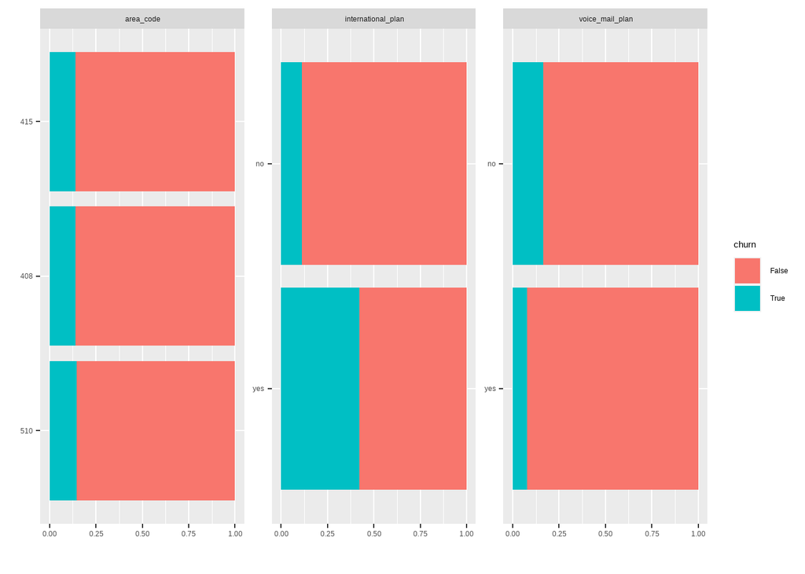

```r
DataExplorer::plot_bar(datos, by = "churn")
```

En cuanto a las proporciones de las variables categoricas respecto a churn: podemos intuir que international plan y quiza voice mail podrían ser influyentes en el churn

```
#> $`0`
```

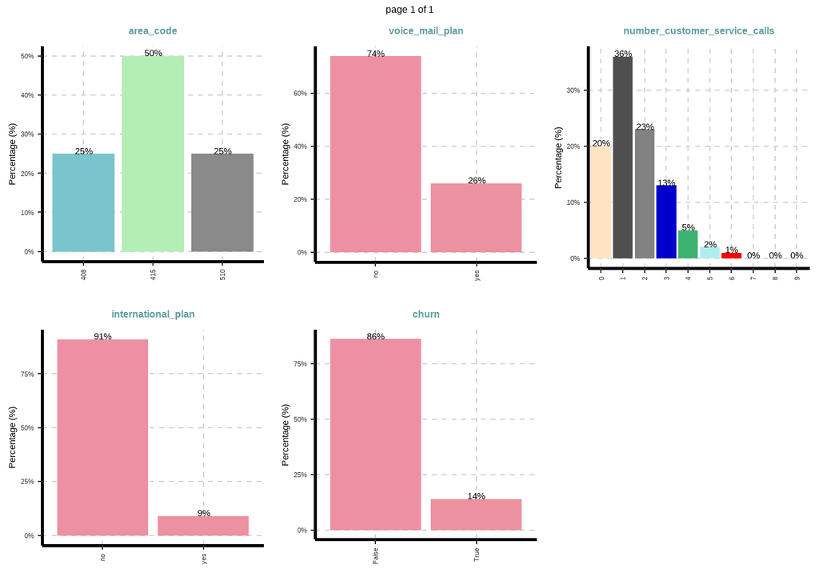

```r
SmartEDA::ExpCatViz(datos, Page = c(2,3))
```

Chrun es el porcentaje de clientes que dejan la telco para pasarse a una compañía de la competencia. Según los datos es el 14%.

Podemos ver que es un dataset donde las categorias están desbalanceadas. En los futuros modelos si siempre se predice *churn = false*, el porcentaje de aciertos será aproximadamente del 85%. Este es el porcentaje mínimo que hay que intentar superar con los modelos predictivos.

## Exploración variables numéricas con estadísticas descriptivas

```r
datos %>%
 dlookr::diagnose_numeric() %>%
  flextable()
```

| variables | min | Q1 | mean | median | Q3 | max | zero | minus | outlier |
| --- | --- | --- | --- | --- | --- | --- | --- | --- | --- |
| number_vmail_messages | 0 | 0.000 | 7.755200 | 0.00 | 17.00 | 52.00 | 3,678 | 0 | 60 |
| total_day_minutes | 0 | 143.700 | 180.288900 | 180.10 | 216.20 | 351.50 | 2 | 0 | 34 |
| total_day_calls | 0 | 87.000 | 119.834000 | 100.00 | 113.00 | 9,999.00 | 2 | 0 | 45 |
| total_day_charge | 0 | 24.430 | 30.649668 | 30.62 | 36.75 | 59.76 | 2 | 0 | 34 |
| total_eve_minutes | 0 | 166.375 | 200.636560 | 201.00 | 234.10 | 363.70 | 1 | 0 | 42 |
| total_eve_calls | 0 | 87.000 | 100.191000 | 100.00 | 114.00 | 170.00 | 1 | 0 | 27 |
| total_eve_charge | 0 | 14.140 | 17.054322 | 17.09 | 19.90 | 30.91 | 1 | 0 | 42 |
| total_night_minutes | 0 | 166.900 | 200.391620 | 200.40 | 234.70 | 395.00 | 1 | 0 | 39 |
| total_night_calls | 0 | 87.000 | 99.919200 | 100.00 | 113.00 | 175.00 | 1 | 0 | 43 |
| total_night_charge | 0 | 7.510 | 9.017732 | 9.02 | 10.56 | 17.77 | 1 | 0 | 39 |
| total_intl_minutes | 0 | 8.500 | 10.261780 | 10.30 | 12.00 | 20.00 | 24 | 0 | 72 |
| total_intl_calls | 0 | 3.000 | 4.435200 | 4.00 | 6.00 | 20.00 | 24 | 0 | 118 |
| total_intl_charge | 0 | 2.300 | 2.771196 | 2.78 | 3.24 | 5.40 | 24 | 0 | 72 |
| number_customer_service_calls | 0 | 1.000 | 1.570400 | 1.00 | 2.00 | 9.00 | 1,023 | 0 | 399 |

```r
SmartEDA::ExpNumStat(datos, by="GA", gp="churn", Outlier=TRUE, Qnt = c(.25, .75), round = 2) %>% flextable()
```

| Vname | Group | TN | nNeg | nZero | nPos | NegInf | PosInf | NA_Value | Per_of_Missing | sum | min | max | mean | median | SD | CV | IQR | Skewness | Kurtosis | 25% | 75% | LB.25% | UB.75% | nOutliers |
| --- | --- | --- | --- | --- | --- | --- | --- | --- | --- | --- | --- | --- | --- | --- | --- | --- | --- | --- | --- | --- | --- | --- | --- | --- |
| number_customer_service_calls | churn:All | 5,000 | 0 | 1,023 | 3,977 | 0 | 0 | 0 | 0 | 7,852.00 | 0.00 | 9.00 | 1.57 | 1.00 | 1.31 | 0.83 | 1.00 | 1.04 | 1.48 | 1.00 | 2.00 | -0.50 | 3.50 | 399 |
| number_customer_service_calls | churn:False | 4,293 | 0 | 902 | 3,391 | 0 | 0 | 0 | 0 | 6,258.00 | 0.00 | 8.00 | 1.46 | 1.00 | 1.16 | 0.80 | 1.00 | 0.86 | 1.07 | 1.00 | 2.00 | -0.50 | 3.50 | 198 |
| number_customer_service_calls | churn:True | 707 | 0 | 121 | 586 | 0 | 0 | 0 | 0 | 1,594.00 | 0.00 | 9.00 | 2.25 | 2.00 | 1.82 | 0.81 | 3.00 | 0.65 | -0.25 | 1.00 | 4.00 | -3.50 | 8.50 | 2 |
| number_vmail_messages | churn:All | 5,000 | 0 | 3,678 | 1,322 | 0 | 0 | 0 | 0 | 38,776.00 | 0.00 | 52.00 | 7.76 | 0.00 | 13.55 | 1.75 | 17.00 | 1.35 | 0.20 | 0.00 | 17.00 | -25.50 | 42.50 | 60 |
| number_vmail_messages | churn:False | 4,293 | 0 | 3,073 | 1,220 | 0 | 0 | 0 | 0 | 35,597.00 | 0.00 | 52.00 | 8.29 | 0.00 | 13.81 | 1.67 | 20.00 | 1.24 | -0.08 | 0.00 | 20.00 | -30.00 | 50.00 | 2 |
| number_vmail_messages | churn:True | 707 | 0 | 605 | 102 | 0 | 0 | 0 | 0 | 3,179.00 | 0.00 | 48.00 | 4.50 | 0.00 | 11.30 | 2.51 | 0.00 | 2.27 | 3.58 | 0.00 | 0.00 | 0.00 | 0.00 | 102 |
| total_day_calls | churn:All | 5,000 | 0 | 2 | 4,998 | 0 | 0 | 0 | 0 | 599,170.00 | 0.00 | 9,999.00 | 119.83 | 100.00 | 442.74 | 3.69 | 26.00 | 22.23 | 493.01 | 87.00 | 113.00 | 48.00 | 152.00 | 45 |
| total_day_calls | churn:False | 4,293 | 0 | 1 | 4,292 | 0 | 0 | 0 | 0 | 527,892.00 | 0.00 | 9,999.00 | 122.97 | 100.00 | 477.67 | 3.88 | 26.00 | 20.59 | 422.86 | 87.00 | 113.00 | 48.00 | 152.00 | 33 |
| total_day_calls | churn:True | 707 | 0 | 1 | 706 | 0 | 0 | 0 | 0 | 71,278.00 | 0.00 | 165.00 | 100.82 | 101.00 | 20.76 | 0.21 | 27.00 | -0.21 | 0.68 | 88.00 | 115.00 | 47.50 | 155.50 | 12 |
| total_day_charge | churn:All | 5,000 | 0 | 2 | 4,998 | 0 | 0 | 0 | 0 | 153,248.34 | 0.00 | 59.76 | 30.65 | 30.62 | 9.16 | 0.30 | 12.32 | -0.01 | -0.02 | 24.43 | 36.75 | 5.95 | 55.23 | 34 |
| total_day_charge | churn:False | 4,293 | 0 | 1 | 4,292 | 0 | 0 | 0 | 0 | 128,264.08 | 0.00 | 53.65 | 29.88 | 30.26 | 8.44 | 0.28 | 11.53 | -0.22 | -0.02 | 24.29 | 35.82 | 6.99 | 53.12 | 25 |
| total_day_charge | churn:True | 707 | 0 | 1 | 706 | 0 | 0 | 0 | 0 | 24,984.26 | 0.00 | 59.76 | 35.34 | 36.70 | 11.66 | 0.33 | 19.20 | -0.16 | -0.88 | 26.09 | 45.30 | -2.71 | 74.10 | 0 |
| total_day_minutes | churn:All | 5,000 | 0 | 2 | 4,998 | 0 | 0 | 0 | 0 | 901,444.50 | 0.00 | 351.50 | 180.29 | 180.10 | 53.89 | 0.30 | 72.50 | -0.01 | -0.02 | 143.70 | 216.20 | 34.95 | 324.95 | 34 |
| total_day_minutes | churn:False | 4,293 | 0 | 1 | 4,292 | 0 | 0 | 0 | 0 | 754,480.00 | 0.00 | 315.60 | 175.75 | 178.00 | 49.63 | 0.28 | 67.80 | -0.22 | -0.02 | 142.90 | 210.70 | 41.20 | 312.40 | 26 |
| total_day_minutes | churn:True | 707 | 0 | 1 | 706 | 0 | 0 | 0 | 0 | 146,964.50 | 0.00 | 351.50 | 207.87 | 215.90 | 68.58 | 0.33 | 112.95 | -0.16 | -0.88 | 153.50 | 266.45 | -15.93 | 435.88 | 0 |
| total_eve_calls | churn:All | 5,000 | 0 | 1 | 4,999 | 0 | 0 | 0 | 0 | 500,955.00 | 0.00 | 170.00 | 100.19 | 100.00 | 19.83 | 0.20 | 27.00 | -0.02 | 0.12 | 87.00 | 114.00 | 46.50 | 154.50 | 27 |
| total_eve_calls | churn:False | 4,293 | 0 | 1 | 4,292 | 0 | 0 | 0 | 0 | 430,337.00 | 0.00 | 170.00 | 100.24 | 101.00 | 19.86 | 0.20 | 27.00 | -0.04 | 0.16 | 87.00 | 114.00 | 46.50 | 154.50 | 25 |
| total_eve_calls | churn:True | 707 | 0 | 0 | 707 | 0 | 0 | 0 | 0 | 70,618.00 | 48.00 | 168.00 | 99.88 | 99.00 | 19.62 | 0.20 | 27.00 | 0.10 | -0.17 | 86.50 | 113.50 | 46.00 | 154.00 | 2 |
| total_eve_charge | churn:All | 5,000 | 0 | 1 | 4,999 | 0 | 0 | 0 | 0 | 85,271.61 | 0.00 | 30.91 | 17.05 | 17.09 | 4.30 | 0.25 | 5.76 | -0.01 | 0.05 | 14.14 | 19.90 | 5.50 | 28.54 | 42 |
| total_eve_charge | churn:False | 4,293 | 0 | 1 | 4,292 | 0 | 0 | 0 | 0 | 72,545.92 | 0.00 | 30.75 | 16.90 | 16.96 | 4.26 | 0.25 | 5.77 | -0.03 | 0.08 | 13.98 | 19.75 | 5.33 | 28.41 | 35 |
| total_eve_charge | churn:True | 707 | 0 | 0 | 707 | 0 | 0 | 0 | 0 | 12,725.69 | 6.03 | 30.91 | 18.00 | 17.94 | 4.38 | 0.24 | 6.25 | 0.05 | -0.21 | 14.95 | 21.19 | 5.58 | 30.56 | 1 |
| total_eve_minutes | churn:All | 5,000 | 0 | 1 | 4,999 | 0 | 0 | 0 | 0 | 1,003,182.80 | 0.00 | 363.70 | 200.64 | 201.00 | 50.55 | 0.25 | 67.72 | -0.01 | 0.05 | 166.38 | 234.10 | 64.79 | 335.69 | 43 |
| total_eve_minutes | churn:False | 4,293 | 0 | 1 | 4,292 | 0 | 0 | 0 | 0 | 853,470.00 | 0.00 | 361.80 | 198.81 | 199.50 | 50.15 | 0.25 | 67.80 | -0.03 | 0.08 | 164.50 | 232.30 | 62.80 | 334.00 | 36 |
| total_eve_minutes | churn:True | 707 | 0 | 0 | 707 | 0 | 0 | 0 | 0 | 149,712.80 | 70.90 | 363.70 | 211.76 | 211.10 | 51.57 | 0.24 | 73.45 | 0.05 | -0.21 | 175.85 | 249.30 | 65.68 | 359.48 | 1 |
| total_intl_calls | churn:All | 5,000 | 0 | 24 | 4,976 | 0 | 0 | 0 | 0 | 22,176.00 | 0.00 | 20.00 | 4.44 | 4.00 | 2.46 | 0.55 | 3.00 | 1.36 | 3.26 | 3.00 | 6.00 | -1.50 | 10.50 | 118 |
| total_intl_calls | churn:False | 4,293 | 0 | 23 | 4,270 | 0 | 0 | 0 | 0 | 19,241.00 | 0.00 | 19.00 | 4.48 | 4.00 | 2.44 | 0.54 | 3.00 | 1.32 | 3.06 | 3.00 | 6.00 | -1.50 | 10.50 | 99 |
| total_intl_calls | churn:True | 707 | 0 | 1 | 706 | 0 | 0 | 0 | 0 | 2,935.00 | 0.00 | 20.00 | 4.15 | 4.00 | 2.55 | 0.61 | 3.00 | 1.65 | 4.57 | 2.00 | 5.00 | -2.50 | 9.50 | 29 |
| total_intl_charge | churn:All | 5,000 | 0 | 24 | 4,976 | 0 | 0 | 0 | 0 | 13,855.98 | 0.00 | 5.40 | 2.77 | 2.78 | 0.75 | 0.27 | 0.94 | -0.21 | 0.65 | 2.30 | 3.24 | 0.89 | 4.65 | 72 |
| total_intl_charge | churn:False | 4,293 | 0 | 23 | 4,270 | 0 | 0 | 0 | 0 | 11,814.57 | 0.00 | 5.32 | 2.75 | 2.78 | 0.74 | 0.27 | 0.94 | -0.25 | 0.73 | 2.30 | 3.24 | 0.89 | 4.65 | 62 |
| total_intl_charge | churn:True | 707 | 0 | 1 | 706 | 0 | 0 | 0 | 0 | 2,041.41 | 0.00 | 5.40 | 2.89 | 2.86 | 0.75 | 0.26 | 1.08 | -0.02 | 0.10 | 2.38 | 3.46 | 0.76 | 5.08 | 4 |
| total_intl_minutes | churn:All | 5,000 | 0 | 24 | 4,976 | 0 | 0 | 0 | 0 | 51,308.90 | 0.00 | 20.00 | 10.26 | 10.30 | 2.76 | 0.27 | 3.50 | -0.21 | 0.65 | 8.50 | 12.00 | 3.25 | 17.25 | 72 |
| total_intl_minutes | churn:False | 4,293 | 0 | 23 | 4,270 | 0 | 0 | 0 | 0 | 43,749.40 | 0.00 | 19.70 | 10.19 | 10.30 | 2.75 | 0.27 | 3.50 | -0.25 | 0.73 | 8.50 | 12.00 | 3.25 | 17.25 | 62 |
| total_intl_minutes | churn:True | 707 | 0 | 1 | 706 | 0 | 0 | 0 | 0 | 7,559.50 | 0.00 | 20.00 | 10.69 | 10.60 | 2.79 | 0.26 | 4.00 | -0.02 | 0.11 | 8.80 | 12.80 | 2.80 | 18.80 | 4 |
| total_night_calls | churn:All | 5,000 | 0 | 1 | 4,999 | 0 | 0 | 0 | 0 | 499,596.00 | 0.00 | 175.00 | 99.92 | 100.00 | 19.96 | 0.20 | 26.00 | 0.00 | 0.14 | 87.00 | 113.00 | 48.00 | 152.00 | 43 |
| total_night_calls | churn:False | 4,293 | 0 | 1 | 4,292 | 0 | 0 | 0 | 0 | 429,196.00 | 0.00 | 175.00 | 99.98 | 100.00 | 19.96 | 0.20 | 26.00 | 0.00 | 0.20 | 87.00 | 113.00 | 48.00 | 152.00 | 38 |
| total_night_calls | churn:True | 707 | 0 | 0 | 707 | 0 | 0 | 0 | 0 | 70,400.00 | 42.00 | 158.00 | 99.58 | 100.00 | 19.97 | 0.20 | 29.00 | 0.04 | -0.20 | 85.00 | 114.00 | 41.50 | 157.50 | 1 |
| total_night_charge | churn:All | 5,000 | 0 | 1 | 4,999 | 0 | 0 | 0 | 0 | 45,088.66 | 0.00 | 17.77 | 9.02 | 9.02 | 2.27 | 0.25 | 3.05 | 0.02 | 0.08 | 7.51 | 10.56 | 2.93 | 15.14 | 39 |
| total_night_charge | churn:False | 4,293 | 0 | 1 | 4,292 | 0 | 0 | 0 | 0 | 38,532.22 | 0.00 | 17.77 | 8.98 | 8.96 | 2.28 | 0.25 | 3.03 | 0.02 | 0.08 | 7.47 | 10.50 | 2.92 | 15.04 | 34 |
| total_night_charge | churn:True | 707 | 0 | 0 | 707 | 0 | 0 | 0 | 0 | 6,556.44 | 2.13 | 17.17 | 9.27 | 9.28 | 2.24 | 0.24 | 3.11 | 0.00 | 0.10 | 7.73 | 10.84 | 3.07 | 15.50 | 5 |
| total_night_minutes | churn:All | 5,000 | 0 | 1 | 4,999 | 0 | 0 | 0 | 0 | 1,001,958.10 | 0.00 | 395.00 | 200.39 | 200.40 | 50.53 | 0.25 | 67.80 | 0.02 | 0.08 | 166.90 | 234.70 | 65.20 | 336.40 | 39 |
| total_night_minutes | churn:False | 4,293 | 0 | 1 | 4,292 | 0 | 0 | 0 | 0 | 856,260.80 | 0.00 | 395.00 | 199.46 | 199.00 | 50.61 | 0.25 | 67.50 | 0.02 | 0.08 | 165.90 | 233.40 | 64.65 | 334.65 | 34 |
| total_night_minutes | churn:True | 707 | 0 | 0 | 707 | 0 | 0 | 0 | 0 | 145,697.30 | 47.40 | 381.60 | 206.08 | 206.30 | 49.69 | 0.24 | 69.10 | 0.00 | 0.10 | 171.75 | 240.85 | 68.10 | 344.50 | 5 |

Se detectan valores 0 y outliers

## **Distribución de variables continuas**

Muchas pruebas estadísticas dependen de datos simétricos y normalmente distribuidos

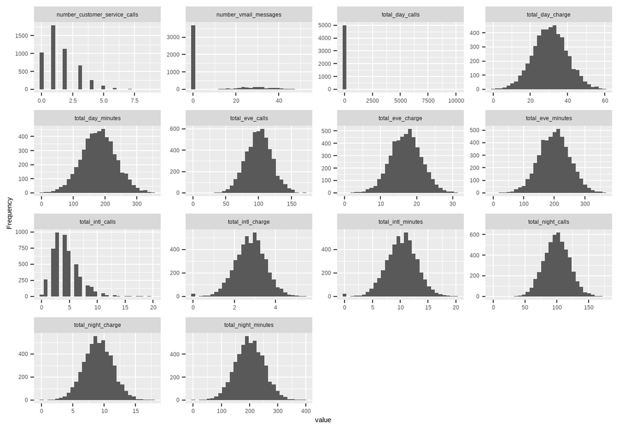

```r
DataExplorer::plot_histogram(datos)
```

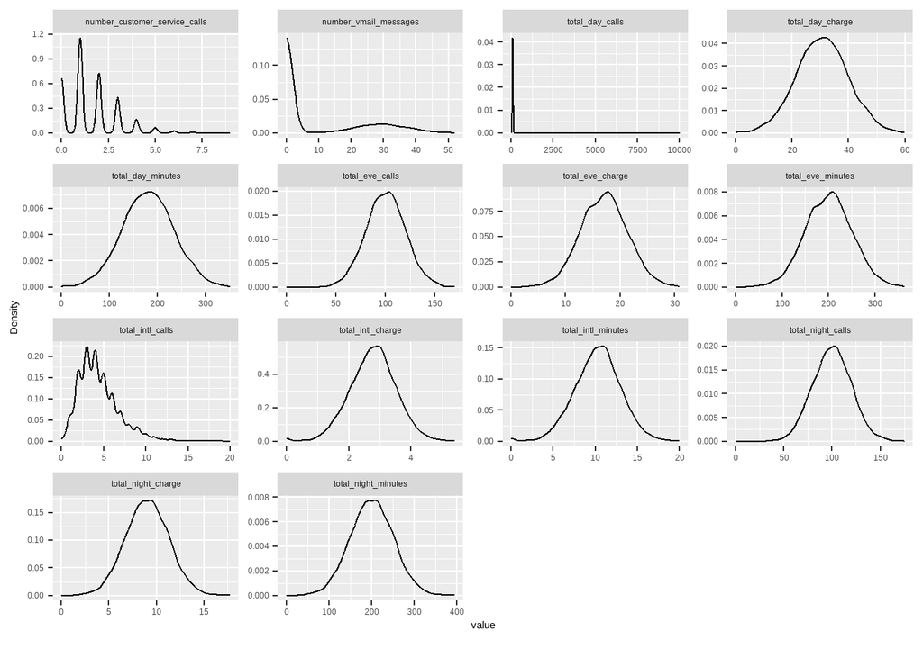

```r
DataExplorer::plot_density(datos)
```

La mayoria de las variables tienen distribución normal Se detectan fluctuaciones en varias variables. *Number of custumer* total day calls se podria categorizar. Total *intl calls* puede tener outliers influyentes

# Normalidad de las variables

Hay dos formas principales de comprobar la normalidad: utilizando un gráfico cuantil-cuantil y utilizando una prueba estadística adecuada. ¡Y los necesitamos a ambos!

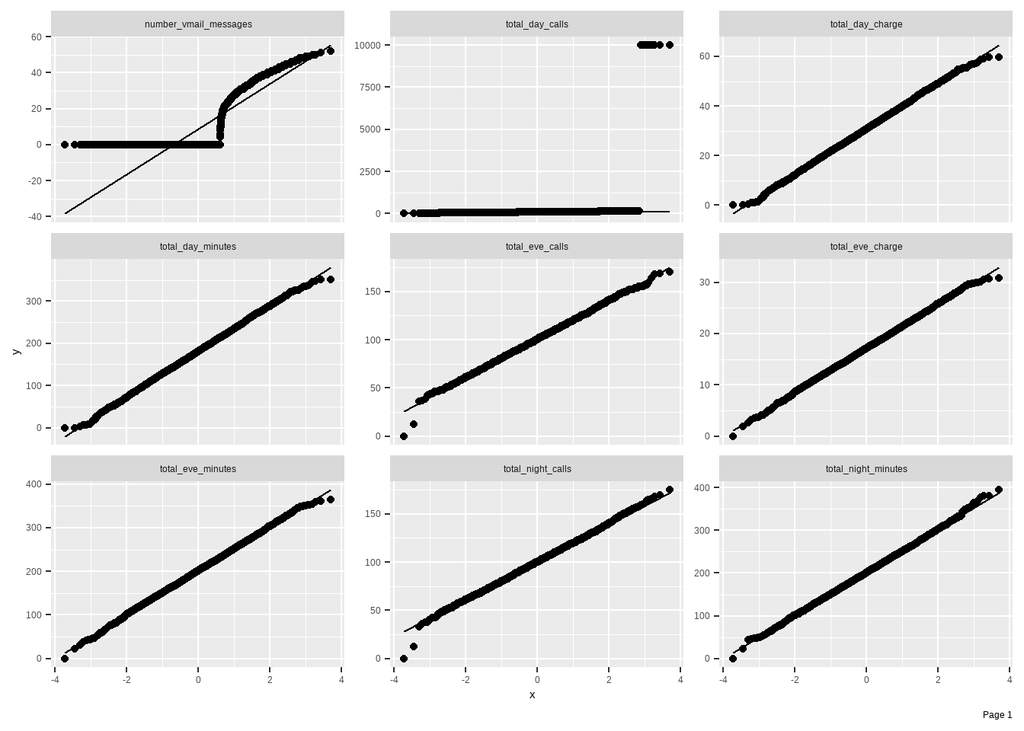

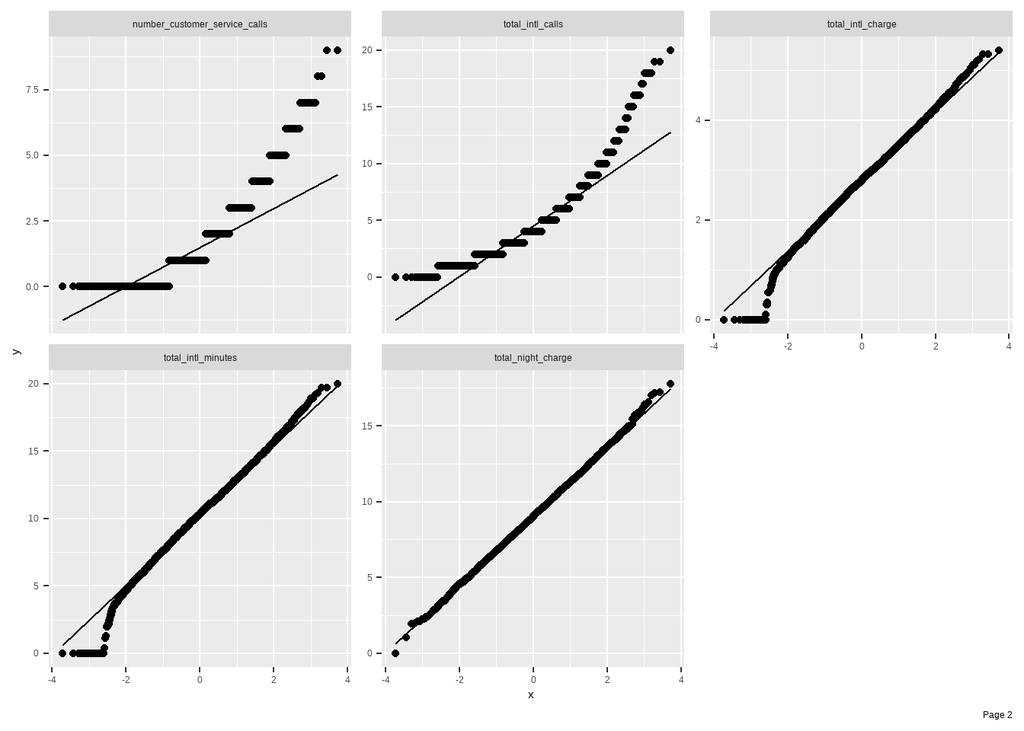

```r
DataExplorer::plot_qq(datos)
```

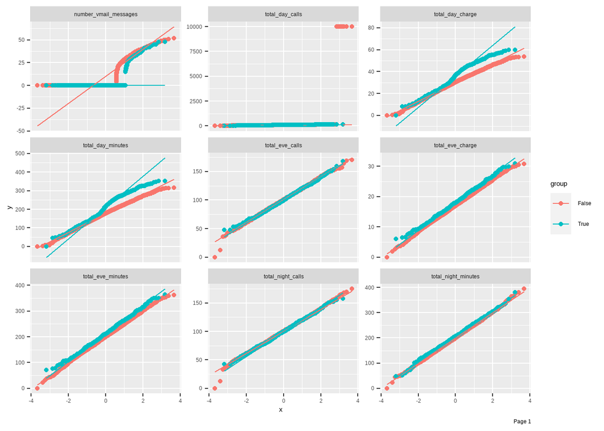

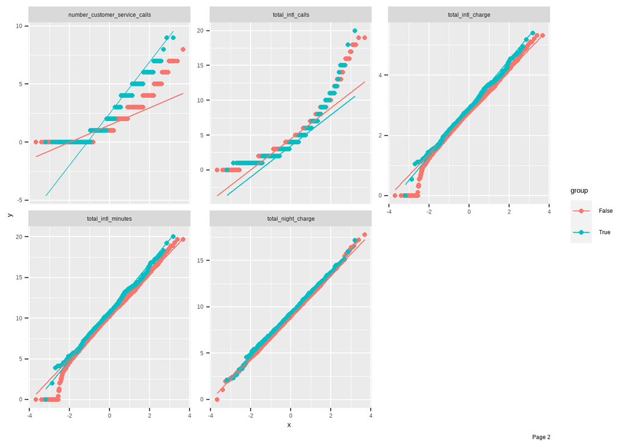

```r
DataExplorer::plot_qq(datos, by = "churn")
```

number of custumer calls parece relevante según el gráfico

```r
normality(datos) %>%
  mutate(across(where(is.numeric), round,3)) %>% flextable()
```

| vars | statistic | p_value | sample |
| --- | --- | --- | --- |
| number_vmail_messages | 0.609 | 0.000 | 5,000 |
| total_day_minutes | 1.000 | 0.515 | 5,000 |
| total_day_calls | 0.035 | 0.000 | 5,000 |
| total_day_charge | 1.000 | 0.515 | 5,000 |
| total_eve_minutes | 1.000 | 0.581 | 5,000 |
| total_eve_calls | 0.999 | 0.009 | 5,000 |
| total_eve_charge | 1.000 | 0.579 | 5,000 |
| total_night_minutes | 1.000 | 0.846 | 5,000 |
| total_night_calls | 0.999 | 0.008 | 5,000 |
| total_night_charge | 1.000 | 0.840 | 5,000 |
| total_intl_minutes | 0.994 | 0.000 | 5,000 |
| total_intl_calls | 0.902 | 0.000 | 5,000 |
| total_intl_charge | 0.994 | 0.000 | 5,000 |
| number_customer_service_calls | 0.880 | 0.000 | 5,000 |

Excepto en las variables que podriamos categorizar se aprecia normalidad. Las variables donde el test de normalidad indica no normalidad puede ser debido a outliers ya que en el qqplot se aprecia que lo son.

# Exploración variables categóricas y numéricas hipotesis testing

En primer lugar, la función tbl_summary() del paquete {gtsummary} resume todas las variables categóricas mediante recuentos y porcentajes, mientras que todas las variables numéricas según la mediana y el IQR. El argumento by = dentro de tbl_summary() especifica una variable de agrupación. Luego, la función add_p() realiza pruebas estadísticas con todas las variables y proporciona valores p. Para las variables numéricas, utiliza la prueba no paramétrica de suma de rangos de Wilcoxon para comparar dos grupos y la prueba no paramétrica de suma de rangos de Kruskal-Wallis para más de dos grupos. Las variables categóricas se verifican con la prueba exacta de Fisher, si el número de observaciones en alguno de los grupos es inferior a 5, o con la prueba Chi-cuadrado de Pearson para obtener más datos.

```r
datos %>%
  #select(survived, sex, parch, pclass, sib_sp) %>%
  gtsummary::tbl_summary(by = churn) %>%
 gtsummary::add_p()
```

| **Characteristic** | **False**, N = 4,293<sup>1</sup> | **True**, N = 707<sup>1</sup> | **p-value**<sup>2</sup> |
| --- | --- | --- | --- |
| state |  |  | <0.001 |
| AK | 67 (1.6%) | 5 (0.7%) |  |
| AL | 111 (2.6%) | 13 (1.8%) |  |
| AR | 76 (1.8%) | 16 (2.3%) |  |
| AZ | 80 (1.9%) | 9 (1.3%) |  |
| CA | 38 (0.9%) | 14 (2.0%) |  |
| CO | 85 (2.0%) | 11 (1.6%) |  |
| CT | 83 (1.9%) | 16 (2.3%) |  |
| DC | 79 (1.8%) | 9 (1.3%) |  |
| DE | 79 (1.8%) | 15 (2.1%) |  |
| FL | 78 (1.8%) | 12 (1.7%) |  |
| GA | 73 (1.7%) | 10 (1.4%) |  |
| HI | 81 (1.9%) | 5 (0.7%) |  |
| IA | 61 (1.4%) | 8 (1.1%) |  |
| ID | 105 (2.4%) | 14 (2.0%) |  |
| IL | 81 (1.9%) | 7 (1.0%) |  |
| IN | 84 (2.0%) | 14 (2.0%) |  |
| KS | 81 (1.9%) | 18 (2.5%) |  |
| KY | 84 (2.0%) | 15 (2.1%) |  |
| LA | 75 (1.7%) | 7 (1.0%) |  |
| MA | 86 (2.0%) | 17 (2.4%) |  |
| MD | 81 (1.9%) | 21 (3.0%) |  |
| ME | 84 (2.0%) | 19 (2.7%) |  |
| MI | 85 (2.0%) | 18 (2.5%) |  |
| MN | 105 (2.4%) | 20 (2.8%) |  |
| MO | 81 (1.9%) | 12 (1.7%) |  |
| MS | 82 (1.9%) | 17 (2.4%) |  |
| MT | 78 (1.8%) | 21 (3.0%) |  |
| NC | 79 (1.8%) | 12 (1.7%) |  |
| ND | 78 (1.8%) | 10 (1.4%) |  |
| NE | 82 (1.9%) | 6 (0.8%) |  |
| NH | 83 (1.9%) | 12 (1.7%) |  |
| NJ | 84 (2.0%) | 28 (4.0%) |  |
| NM | 81 (1.9%) | 10 (1.4%) |  |
| NV | 73 (1.7%) | 17 (2.4%) |  |
| NY | 94 (2.2%) | 20 (2.8%) |  |
| OH | 101 (2.4%) | 15 (2.1%) |  |
| OK | 74 (1.7%) | 16 (2.3%) |  |
| OR | 96 (2.2%) | 18 (2.5%) |  |
| PA | 69 (1.6%) | 8 (1.1%) |  |
| RI | 92 (2.1%) | 7 (1.0%) |  |
| SC | 75 (1.7%) | 16 (2.3%) |  |
| SD | 73 (1.7%) | 12 (1.7%) |  |
| TN | 75 (1.7%) | 14 (2.0%) |  |
| TX | 90 (2.1%) | 26 (3.7%) |  |
| UT | 96 (2.2%) | 16 (2.3%) |  |
| VA | 112 (2.6%) | 6 (0.8%) |  |
| VT | 91 (2.1%) | 10 (1.4%) |  |
| WA | 74 (1.7%) | 24 (3.4%) |  |
| WI | 98 (2.3%) | 8 (1.1%) |  |
| WV | 136 (3.2%) | 22 (3.1%) |  |
| WY | 104 (2.4%) | 11 (1.6%) |  |
| area_code |  |  | 0.8 |
| 408 | 1,082 (25%) | 177 (25%) |  |
| 415 | 2,149 (50%) | 346 (49%) |  |
| 510 | 1,062 (25%) | 184 (26%) |  |
| international_plan | 274 (6.4%) | 199 (28%) | <0.001 |
| voice_mail_plan | 1,221 (28%) | 102 (14%) | <0.001 |
| number_vmail_messages | 0 (0, 20) | 0 (0, 0) | <0.001 |
| total_day_minutes | 178 (143, 211) | 216 (154, 266) | <0.001 |
| total_day_calls | 100 (87, 113) | 101 (88, 115) | 0.2 |
| total_day_charge | 30 (24, 36) | 37 (26, 45) | <0.001 |
| total_eve_minutes | 200 (165, 232) | 211 (176, 249) | <0.001 |
| total_eve_calls | 101 (87, 114) | 99 (87, 114) | 0.5 |
| total_eve_charge | 17.0 (14.0, 19.8) | 17.9 (14.9, 21.2) | <0.001 |
| total_night_minutes | 199 (166, 233) | 206 (172, 241) | 0.002 |
| total_night_calls | 100 (87, 113) | 100 (85, 114) | 0.6 |
| total_night_charge | 8.96 (7.47, 10.50) | 9.28 (7.73, 10.84) | 0.002 |
| total_intl_minutes | 10.30 (8.50, 12.00) | 10.60 (8.80, 12.80) | <0.001 |
| total_intl_calls | 4.00 (3.00, 6.00) | 4.00 (2.00, 5.00) | <0.001 |
| total_intl_charge | 2.78 (2.30, 3.24) | 2.86 (2.38, 3.46) | <0.001 |
| number_customer_service_calls | 1.00 (1.00, 2.00) | 2.00 (1.00, 4.00) | <0.001 |

<sup>1</sup> n (%); Median (IQR)  
<sup>2</sup> Pearson’s Chi-squared test; Wilcoxon rank sum test

## Exploramos correlaciones

Las variables correlacionadas son redundantes para los modelos

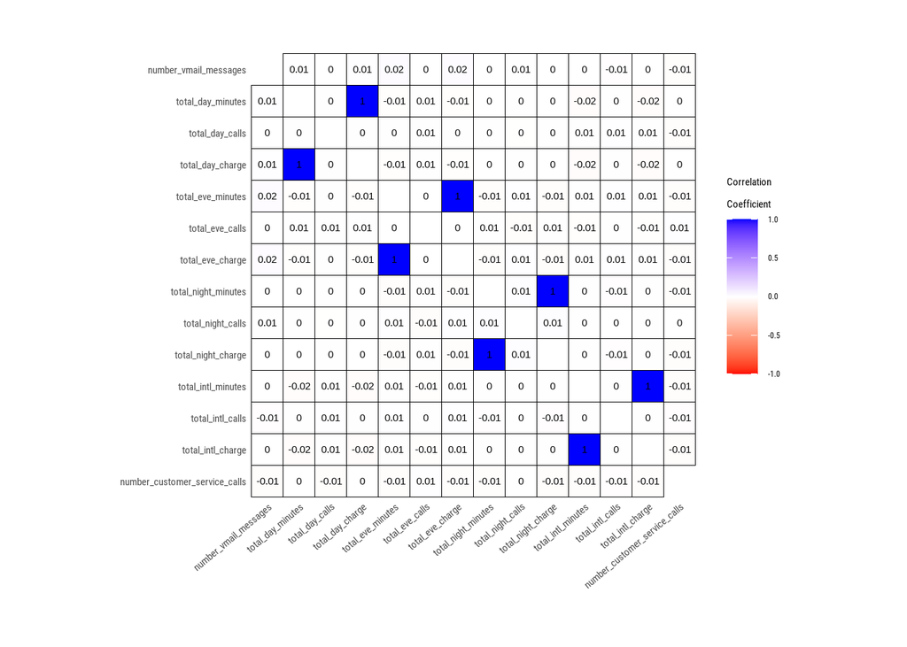

```r
dlookr::plot_correlate(datos, method = "kendall")
```

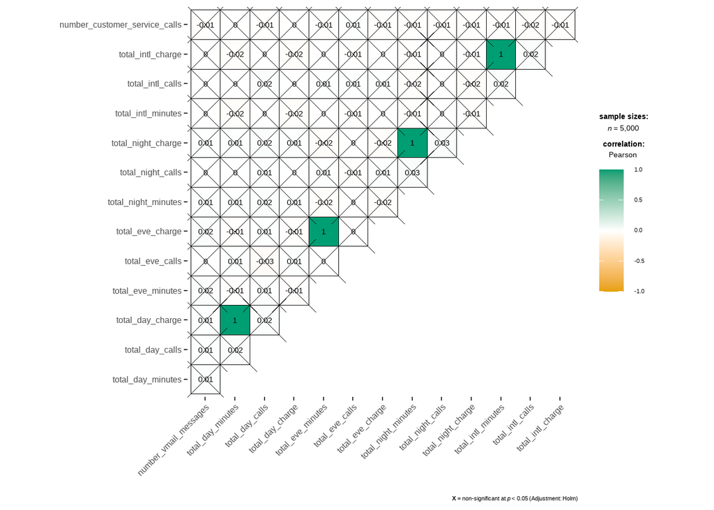

```r
ggstatsplot::ggcorrmat(data = datos)
```

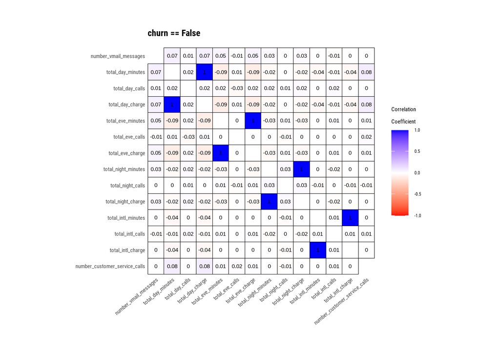

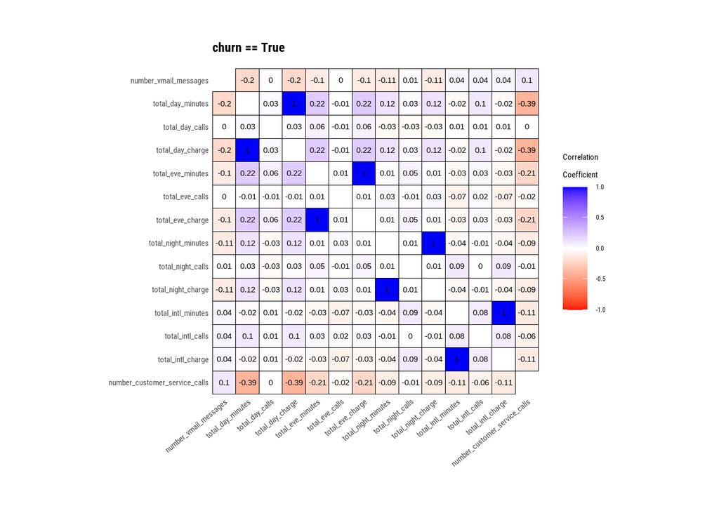

```r
datos %>%
  group_by(churn) %>%
  plot_correlate()
```

Podríamos limitarnos a usar cargos en vez de los totales, pero desconozco si la compañia tiene planes para diferentes usuarios y por ello no las voy a eliminar aunque tengan información redundante.

# Genera una nueva variable categórica de 2 niveles que agrupe de alguna manera a los clientes por niveles de consumo

Usaré la mediana de la variable total_day_charge para crear una variable consumo debajo de la mediana: bajo, por encima: elevado

```r
datos$consumo <- if_else(datos$total_day_charge >= 30.62, "Elevado", "Bajo")
datos$consumo <- factor(datos$consumo)
glimpse(datos)
```

```
#> Rows: 5,000
#> Columns: 20
#> $ state                         <fct> KS, OH, NJ, OH, OK, AL, MA, MO, LA, WV, …
#> $ area_code                     <fct> 415, 415, 415, 408, 415, 510, 510, 415, …
#> $ international_plan            <fct> no, no, no, yes, yes, yes, no, yes, no, …
#> $ voice_mail_plan               <fct> yes, yes, no, no, no, no, yes, no, no, y…
#> $ number_vmail_messages         <dbl> 25, 26, 0, 0, 0, 0, 24, 0, 0, 37, 0, 0, …
#> $ total_day_minutes             <dbl> 265.1, 161.6, 243.4, 299.4, 166.7, 223.4…
#> $ total_day_calls               <dbl> 110, 123, 114, 71, 113, 98, 88, 79, 97, …
#> $ total_day_charge              <dbl> 45.07, 27.47, 41.38, 50.90, 28.34, 37.98…
#> $ total_eve_minutes             <dbl> 197.4, 195.5, 121.2, 61.9, 148.3, 220.6,…
#> $ total_eve_calls               <dbl> 99, 103, 110, 88, 122, 101, 108, 94, 80,…
#> $ total_eve_charge              <dbl> 16.78, 16.62, 10.30, 5.26, 12.61, 18.75,…
#> $ total_night_minutes           <dbl> 244.7, 254.4, 162.6, 196.9, 186.9, 203.9…
#> $ total_night_calls             <dbl> 91, 103, 104, 89, 121, 118, 118, 96, 90,…
#> $ total_night_charge            <dbl> 11.01, 11.45, 7.32, 8.86, 8.41, 9.18, 9.…
#> $ total_intl_minutes            <dbl> 10.0, 13.7, 12.2, 6.6, 10.1, 6.3, 7.5, 7…
#> $ total_intl_calls              <dbl> 3, 3, 5, 7, 3, 6, 7, 6, 4, 5, 6, 5, 2, 5…
#> $ total_intl_charge             <dbl> 2.70, 3.70, 3.29, 1.78, 2.73, 1.70, 2.03…
#> $ number_customer_service_calls <dbl> 1, 1, 0, 2, 3, 0, 3, 0, 1, 0, 4, 0, 1, 3…
#> $ churn                         <fct> False, False, False, False, False, False…
#> $ consumo                       <fct> Elevado, Bajo, Elevado, Elevado, Bajo, E…
```

# Modelado

## **División de los datos en entrenamiento y test**

```r
set.seed(123)
# Se crean los índices de las observaciones de entrenamiento
train <- caret::createDataPartition(y = datos$churn, p = 0.8, list = FALSE, times = 1)
datos_train <- datos[train, ]
datos_test  <- datos[-train, ]
```

```r
(distribucion_train <- prop.table(table(datos_train$churn)) %>% round(3))
```

```
#>
#> False  True
#> 0.859 0.141
```

```r
(distribucion_test  <- prop.table(table(datos_test$churn)) %>% round(3))
```

```
#>
#> False  True
#> 0.859 0.141
```

```r
(Tabla_distribucion_completa <- data.frame(train = distribucion_train, test = distribucion_test ))
```

| train.Var1 | train.Freq | test.Var1 | test.Freq |
| --- | --- | --- | --- |
| False | 0.859 | False | 0.859 |
| True | 0.141 | True | 0.141 |

Conservamos la distribución de ambas clases en el reparto.

# Preprocesamiento de los datos

La idea detrás de este paquete es la siguiente:

Definir cuál es la variable respuesta, los predictores y el set de datos de entrenamiento, recipe(). Definir todas las transformaciones (escalado, selección, filtrado…) que se desea aplicar, step_(). Aprender los parámetros necesarios para dichas transformaciones con las observaciones de entrenamiento rep(). Aplicar las trasformaciones aprendidas a cualquier conjunto de datos bake().

```r
objeto_recipe <- recipes::recipe(formula = churn ~ .,
                        data =  datos_train)
objeto_recipe
```

## Variables con varianza próxima a cero

No se deben incluir en el modelo predictores que contengan un único valor (cero-varianza) ya que no aportan información. Tampoco es conveniente incluir predictores que tengan una varianza próxima a cero

```r
objeto_recipe <- objeto_recipe %>% step_nzv(all_predictors())
```

# Estandarización y escalado

para hacer comparables las medidas de las variables cuantitativas

```r
objeto_recipe <- objeto_recipe %>% step_center(all_numeric())
objeto_recipe <- objeto_recipe %>% step_scale(all_numeric())
```

```r
objeto_recipe <- objeto_recipe %>% step_dummy(all_nominal(), -all_outcomes())
```

Una vez que se ha creado el objeto recipe con todas las transformaciones de preprocesado, se aprenden con los datos de entrenamiento y se aplican a los dos conjuntos.

```r
# Se entrena el objeto recipe
trained_recipe <- prep(objeto_recipe, training = datos_train)
trained_recipe
```

```r
# Se aplican las transformaciones al conjunto de entrenamiento y de test
datos_train_prep <- bake(trained_recipe, new_data = datos_train)
datos_test_prep  <- bake(trained_recipe, new_data = datos_test)

glimpse(datos_train_prep)
```

```
#> Rows: 4,001
#> Columns: 69
#> $ total_day_minutes             <dbl> 1.55971012, -0.34606369, 1.16014208, 2.1…
#> $ total_day_calls               <dbl> -0.0174288643, 0.0139551592, -0.00777224…
#> $ total_day_charge              <dbl> 1.55998013, -0.34634229, 1.16030231, 2.1…
#> $ total_eve_minutes             <dbl> -0.06317051, -0.10047375, -1.55922696, -…
#> $ total_eve_calls               <dbl> -0.06819112, 0.13503619, 0.49068398, -0.…
#> $ total_eve_charge              <dbl> -0.06299276, -0.09994959, -1.55974438, -…
#> $ total_night_minutes           <dbl> 0.87694560, 1.06922611, -0.75050074, -0.…
#> $ total_night_calls             <dbl> -0.4468407, 0.1548622, 0.2050041, -0.547…
#> $ total_night_charge            <dbl> 0.87623613, 1.07005541, -0.74920283, -0.…
#> $ total_intl_minutes            <dbl> -0.09098388, 1.24429718, 0.70296702, -1.…
#> $ total_intl_calls              <dbl> -0.5899991, -0.5899991, 0.2214778, 1.032…
#> $ total_intl_charge             <dbl> -0.09172112, 1.24507113, 0.69698631, -1.…
#> $ number_customer_service_calls <dbl> -0.4250937, -0.4250937, -1.1988879, 0.34…
```

[output cut: 56 more lines]

# Modelo

## Modelo random forest

```r
# Función para entrenar  modelo RF

RF_model_func <- function(traindf) {


  # Variables Cross Validation
  particiones  <- 5
  repeticiones <- 5



  # Hiperparámetros
hiperparametros <- expand.grid(mtry = c(2, 5, 10, 50),
                                 min.node.size = c(2, 3, 4, 5, 10),
                                 splitrule = "gini")

  # Generar semillas para CV

  # Iniciamos una lista vacía que almacenará las semillas de aleatoriedad con las
  # que trabajaremos. Haremos 10 folds * 5 repeticiones = lista con 50 bolsillos +
  # 1 para el modelo final (Lo pone en la documentación de ?trainControl() ).
  # Debemos llenar todos los bolsillos con vectores con 50 numeros cada uno, menos
  # en el último bolsillo de la lista semillas, que debe ser un único número.

  semillas <- vector(mode = "list", length = (particiones*repeticiones) +1)


  # Llenamos la lista/vector con semillas al azar, elegidas entre 1 y 1000.
  # Creamos, por tanto, una lista de listas. Todos los bolsillos de la lista,
  # menos el último, tendrán vectores con 16 números de longitud
  #
  # ejemplo: (5 folds * 5 repeticiones) + 1 evaluación final = 51
  # Hemos usado lapply porque queremos que nos devuelva una lista/vector

  semillas <- lapply(semillas, function(x) sample.int(1000, size=nrow(hiperparametros)))

  semillas[[(particiones*repeticiones) +1]] <- sample.int(1000, size= 1)


  #str(semillas)


  #tic() # Inicio conteo tiempo

  # Definir control de entrenamiento con validación cruzada repetida con SMOTE y semillas generadas

  control <- trainControl(method = "repeatedcv", # Método de validación cruzada
                          number = particiones, # Número de particiones
                          repeats = repeticiones, # Número de repeticiones
                          #sampling = "smote", # Método de sobremuestreo (SMOTE)
                          classProbs = TRUE, # Usar probabilidades de clase para predicciones
                          summaryFunction = twoClassSummary, # Métricas de evaluación para clases multiclase
                          seeds = semillas,
                          #summaryFunction = multiClassSummary,
                          verboseIter = T,
                          #summaryFunction = defaultSummary,
                          # selectionFunction = "best",
                          # savePredictions = "final",
                          returnResamp = "final",
                          allowParallel = TRUE) # Semillas para reproducibilidad


  # # Clusters para procesamiento paralelo
  # cl = makePSOCKcluster(1)
  # registerDoParallel(cl)


  set.seed(1993)
  modelo_RF <- train(churn ~ ., data = traindf,
                     method = "ranger",
                     num.trees = 500,
                     trControl = control,
                     tuneGrid = hiperparametros,
                     importance = "impurity",
                     metric = "ROC", # Incluir métricas de evaluación
                     maximize = TRUE) # Indicar que se debe maximizar la métrica MCC

  # finalizamos paralelización
  #stopCluster(cl)

  modelo_RF

  #toc() # fin conteo tiempo

  # Visualizamos optimización hiperparámetros
  ggplot(modelo_RF, highlight = TRUE) +
    scale_x_continuous(breaks = hiperparametros$k) +
    labs(title = "Evolución del accuracy en función de K", x = "K") +
    theme_bw() +
    geom_line(color="blue")

  # La función devuelve el modelo
  return(modelo_RF)
}


### RF - Normal --------------------------------------------------------


# Entrenamos RF
modelo_rf <- RF_model_func(datos_train_prep)

# Predicciones
pred_rf <- predict(modelo_rf,newdata = datos_test_prep, type = "raw")

# Probabilidades Predicciones
prob_rf <- predict(modelo_rf,newdata = datos_test_prep, type = "prob")
```

```r
modelo_rf
```

```
#> Random Forest
#>
#> 4001 samples
#>   68 predictor
#>    2 classes: 'False', 'True'
#>
#> No pre-processing
#> Resampling: Cross-Validated (5 fold, repeated 5 times)
#> Summary of sample sizes: 3201, 3201, 3201, 3200, 3201, 3201, ...
#> Resampling results across tuning parameters:
#>
#>   mtry  min.node.size  ROC        Sens       Spec
#>    2     2             0.9063440  1.0000000  0.09469027
#>    2     3             0.9069937  1.0000000  0.09186462
#>    2     4             0.9063152  1.0000000  0.09400404
#>    2     5             0.9073359  1.0000000  0.08975004
#>    2    10             0.9063857  1.0000000  0.09045179
#>    5     2             0.9150190  0.9977293  0.49431765
#>    5     3             0.9151003  0.9976710  0.49677690
#>    5     4             0.9148594  0.9979622  0.49432386
#>    5     5             0.9151501  0.9980786  0.49821767
#>    5    10             0.9145352  0.9979039  0.48229778
#>   10     2             0.9153450  0.9941776  0.72154634
#>   10     3             0.9152144  0.9943523  0.71447291
#>   10     4             0.9152486  0.9944687  0.71905915
#>   10     5             0.9158094  0.9944687  0.71836361
#>   10    10             0.9152482  0.9940029  0.71446980
#>   50     2             0.9119268  0.9898690  0.74627542
#>   50     3             0.9118928  0.9898108  0.75193293
#>   50     4             0.9125543  0.9899272  0.74874398
#>   50     5             0.9119824  0.9899272  0.74698028
#>   50    10             0.9123935  0.9898690  0.74770067
#>
#> Tuning parameter 'splitrule' was held constant at a value of gini
#> ROC was used to select the optimal model using the largest value.
#> The final values used for the model were mtry = 10, splitrule = gini
#>  and min.node.size = 5.
```

```r
# Matriz confusión
(conf_rf<- caret::confusionMatrix(pred_rf, datos_test_prep$churn, positive= "True"))
```

```
#> Confusion Matrix and Statistics
#>
#>           Reference
#> Prediction False True
#>      False   853   41
#>      True      5  100
#>
#>                Accuracy : 0.954
#>                  95% CI : (0.9391, 0.9661)
#>     No Information Rate : 0.8589
#>     P-Value [Acc > NIR] : < 2.2e-16
#>
#>                   Kappa : 0.7874
#>
#>  Mcnemar's Test P-Value : 2.463e-07
#>
#>             Sensitivity : 0.7092
#>             Specificity : 0.9942
#>          Pos Pred Value : 0.9524
#>          Neg Pred Value : 0.9541
#>              Prevalence : 0.1411
#>          Detection Rate : 0.1001
#>    Detection Prevalence : 0.1051
#>       Balanced Accuracy : 0.8517
#>
#>        'Positive' Class : True
#>
```

## Visualizamos curva roc

```r
predictions <- prob_rf$True
labels <- datos_test_prep$churn
pred <- ROCR::prediction(predictions, labels)
pred
```

```
#> A prediction instance
#>   with 999 data points
```

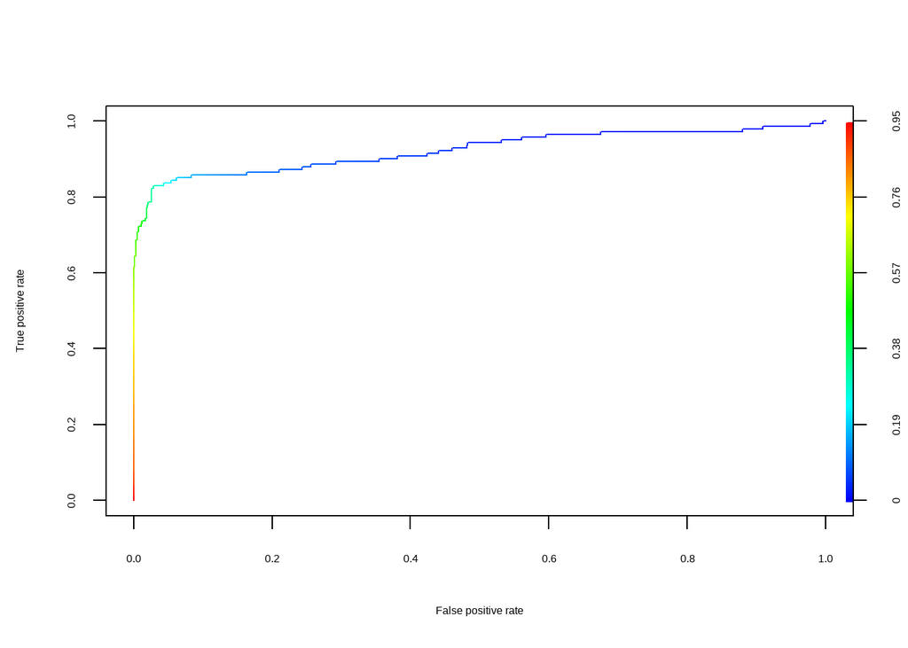

```r
perf <-  ROCR::performance(pred, "tpr", "fpr")
plot(perf, av = "threshold", colorize = TRUE)
```

Las variables más importantes serían:

```r
varImp(modelo_rf)
```

```
#> ranger variable importance
#>
#>   only 20 most important variables shown (out of 68)
#>
#>                               Overall
#> total_day_minutes             100.000
#> total_day_charge               96.736
#> number_customer_service_calls  77.210
#> international_plan_yes         57.468
#> total_eve_minutes              43.659
#> total_eve_charge               42.309
#> total_intl_calls               34.505
#> total_intl_minutes             28.023
#> total_intl_charge              27.874
#> total_night_minutes            26.932
#> total_night_charge             26.455
#> voice_mail_plan_yes            24.530
#> total_day_calls                19.335
#> total_night_calls              18.738
#> total_eve_calls                17.892
#> consumo_Elevado                11.780
#> area_code_X415                  2.439
#> area_code_X510                  2.188
#> state_CA                        1.869
#> state_NJ                        1.740
```

# Probamos con svm Radial

```r
# Función para entrenar  modelo SVML

SVMR_model_func <- function(traindf) {


  # Variables Cross Validation
  particiones  <- 5
  repeticiones <- 3



  # Hiperparámetros
  hiperparametros <- expand.grid(sigma = c(0.0001, 0.001),
                                 C = c(1, 10))

  # Generar semillas para CV

  # Iniciamos una lista vacía que almacenará las semillas de aleatoriedad con las
  # que trabajaremos. Haremos 10 folds * 5 repeticiones = lista con 50 bolsillos +
  # 1 para el modelo final (Lo pone en la documentación de ?trainControl() ).
  # Debemos llenar todos los bolsillos con vectores con 50 numeros cada uno, menos
  # en el último bolsillo de la lista semillas, que debe ser un único número.

  semillas <- vector(mode = "list", length = (particiones*repeticiones) +1)


  # Llenamos la lista/vector con semillas al azar, elegidas entre 1 y 1000.
  # Creamos, por tanto, una lista de listas. Todos los bolsillos de la lista,
  # menos el último, tendrán vectores con 16 números de longitud
  #
  # ejemplo: (10 folds * 5 repeticiones) + 1 evaluación final = 51
  # Hemos usado lapply porque queremos que nos devuelva una lista/vector

  semillas <- lapply(semillas, function(x) sample.int(1000, size=nrow(hiperparametros)))

  semillas[[(particiones*repeticiones) +1]] <- sample.int(1000, size= 1)


  #str(semillas)



  # Definir control de entrenamiento con validación cruzada repetida con SMOTE y semillas generadas

  control <- trainControl(method = "repeatedcv", # Método de validación cruzada
                          number = particiones, # Número de particiones
                          repeats = repeticiones, # Número de repeticiones
                          #sampling = "smote", # Método de sobremuestreo (SMOTE)
                          classProbs = TRUE, # Usar probabilidades de clase para predicciones
                          summaryFunction = twoClassSummary, # Métricas de evaluación para clases multiclase
                          seeds = semillas,
                          #summaryFunction = multiClassSummary,
                          verboseIter = T,
                          #summaryFunction = defaultSummary,
                          # selectionFunction = "best",
                          # savePredictions = "final",
                          returnResamp = "final",
                          allowParallel = TRUE) # Semillas para reproducibilidad





  set.seed(1993)
  modelo_SVMR <- train(churn ~ ., data = traindf,
                       method = "svmRadial",
                       trControl = control,
                       tuneGrid = hiperparametros,
                       metric = "ROC", # Incluir métricas de evaluación
                       maximize = TRUE) # Indicar que se debe maximizar la métrica MCC



  modelo_SVMR



  # Visualizamos optimización hiperparámetros
  ggplot(modelo_SVMR, highlight = TRUE) +
    scale_x_continuous(breaks = hiperparametros$k) +
    labs(title = "Evolución del accuracy en función de K", x = "K") +
    theme_bw() +
    geom_line(color="blue")

  # La función devuelve el modelo
  return(modelo_SVMR)
}
```

```r
### RF - Normal --------------------------------------------------------


# Entrenamos RF
modelo_svmr <- SVMR_model_func(datos_train_prep)
# Predicciones
pred_svmr <- predict(modelo_svmr,newdata = datos_test_prep, type = "raw")

# Probabilidades Predicciones
prob_svmr <- predict(modelo_svmr,newdata = datos_test_prep, type = "prob")
```

```r
modelo_svmr
```

```
#> Support Vector Machines with Radial Basis Function Kernel
#>
#> 4001 samples
#>   68 predictor
#>    2 classes: 'False', 'True'
#>
#> No pre-processing
#> Resampling: Cross-Validated (5 fold, repeated 3 times)
#> Summary of sample sizes: 3201, 3201, 3201, 3200, 3201, 3201, ...
#> Resampling results across tuning parameters:
#>
#>   sigma  C   ROC        Sens       Spec
#>   1e-04   1  0.8180121  0.9974770  0.05352171
#>   1e-04  10  0.8228649  0.9981562  0.04005589
#>   1e-03   1  0.8550932  0.9836972  0.26673394
#>   1e-03  10  0.8555498  0.9789423  0.31096621
#>
#> ROC was used to select the optimal model using the largest value.
#> The final values used for the model were sigma = 0.001 and C = 10.
```

```r
# Matriz confusión
(conf_svmr<- caret::confusionMatrix(pred_svmr, datos_test_prep$churn, positive= "True"))
```

```
#> Confusion Matrix and Statistics
#>
#>           Reference
#> Prediction False True
#>      False   838   79
#>      True     20   62
#>
#>                Accuracy : 0.9009
#>                  95% CI : (0.8807, 0.9187)
#>     No Information Rate : 0.8589
#>     P-Value [Acc > NIR] : 4.101e-05
#>
#>                   Kappa : 0.5046
#>
#>  Mcnemar's Test P-Value : 5.569e-09
#>
#>             Sensitivity : 0.43972
#>             Specificity : 0.97669
#>          Pos Pred Value : 0.75610
#>          Neg Pred Value : 0.91385
#>              Prevalence : 0.14114
#>          Detection Rate : 0.06206
#>    Detection Prevalence : 0.08208
#>       Balanced Accuracy : 0.70820
#>
#>        'Positive' Class : True
#>
```

## Visualizamos curva roc

```r
predictions <- prob_svmr$True
labels <- datos_test_prep$churn
pred <- ROCR::prediction(predictions, labels)
pred
```

```
#> A prediction instance
#>   with 999 data points
```

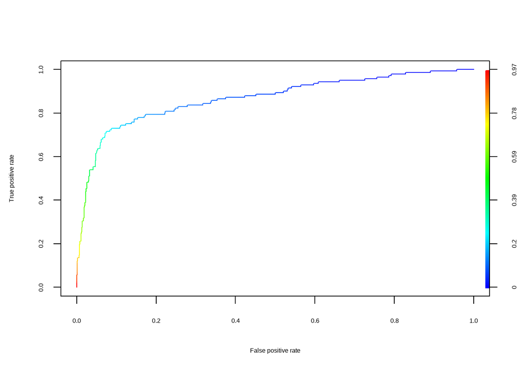

```r
perf <-  ROCR::performance(pred, "tpr", "fpr")
plot(perf, av = "threshold", colorize = TRUE)
```

Random forest sería nuestro modelo a seguir.

# Aplicamos boruta para una selección de características extra:

```r
# Boruta
boruta <-
  Boruta(churn ~ .,
         data = datos_train_prep,
         doTrace = 2,
         maxRuns = 100) # Número de iteraciones





# Tentativa de arreglo provisional de Boruta
# La siguiente decisión sobre los atributos provisionales se basa en comparar
# la puntuación Z mediana de cada atributo con la puntuación Z mediana del
# mejor atributo de sombra. Los atributos que tengan una puntuación Z mediana
# mayor o igual que la del mejor atributo de sombra se clasificarán como
# confirmados, mientras que los que tengan una puntuación Z mediana menor
# se clasificarán como rechazados.
final.boruta <- TentativeRoughFix(boruta)



# vector con los genes (predictores) seleccionados
sel <- getSelectedAttributes(final.boruta, withTentative = F)
sel_formula <- getNonRejectedFormula(final.boruta)
sel_formula
```

```
#> churn ~ total_day_minutes + total_day_charge + total_eve_minutes +
#>     total_eve_charge + total_night_minutes + total_night_charge +
#>     total_intl_minutes + total_intl_calls + total_intl_charge +
#>     number_customer_service_calls + international_plan_yes +
#>     voice_mail_plan_yes + consumo_Elevado
#> <environment: 0x0000026db94e16f0>
```

Las variables seleccionadas por boruta como las más importantes para el modelo serían las siguientes: churn ~ total_day_minutes + total_day_charge + total_eve_minutes + total_eve_charge + total_night_minutes + total_night_charge + total_intl_minutes + total_intl_calls + total_intl_charge + number_customer_service_calls + international_plan_yes + voice_mail_plan_yes + consumo_Elevado

# Ejercicio 4

1- Seleccionaría los clientes que tuvieran las mismas características que los clientes que estén por encima del 75% de la distribución total de todos los clientes en cuestión de consumo

2. Podríamos realizar una segmentación similar a la anterior en basa a la categoría creada de interes, utilizar un algoritmo de clasificación no supervisada de clasificación. Si el nuevo cliente entra dentro del grupo sería un candidato oportuno.